# Discovering Hidden Structures with Unsupervised Learning

> More specifically, we want to answer the following questions:
> - What are k-means clustering and expectation-maximization, and how do I implement these things in OpenCV?
> - How can I arrange clustering algorithms in hierarchical trees, and what are the benefits that come from that?
> - How can I use unsupervised learning for preprocessing, image processing, and classification?

## Understanding k-means clustering

Searches for a predetermined number of *k* clusters within an unlabeled multidimensional dataset. It assumes what an optimal clustering should look like

- The center of each cluster is the arithmetic mean of all the points of the cluster
- Each point in the cluster is closer to its own center than to other cluster centers.

```python
# generate 2d datasets with 4 blobs
import matplotlib.pyplot as plt
%matplotlib inline
plt.style.use('ggplot')
```

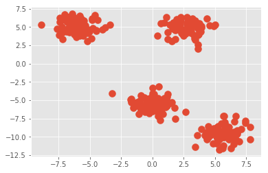

```python
# 300 blobs, four clusters
from sklearn.datasets.samples_generator import make_blobs
X, y_true = make_blobs(n_samples=300, centers=4,\
                      cluster_std=1.0, random_state=10)
plt.scatter(X[:, 0], X[:, 1], s=100);
```

> Although k-means is, of course, a statistical model, in OpenCV, it does not come via the ml module and the common train and predict API calls. Instead, it is directly available as cv2.kmeans. In order to use the model, we have to specify some arguments, such as the termination criteria and some initialization flags.

```python
# terminate the algorithm whenever error < 1.0 or
# ten iterations have passed
import cv2
criteria = (cv2.TERM_CRITERIA_EPS + \
cv2.TERM_CRITERIA_MAX_ITER, 10, 1.0)
flags = cv2.KMEANS_RANDOM_CENTERS
```

```python
# pass the data matrix to cv2.means
import numpy as np
compactness, labels, centers = cv2.kmeans(X.astype(np.float32),\
    4, None, criteria, 10, flags)
```

`compactness` is the sum of squared distances from a point to its cluster center.

```python
compactness
```

```
526.6774351084605
```

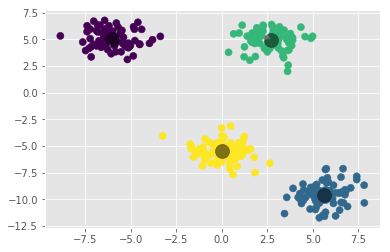

```python
# let's plot the data points to understand it better
plt.scatter(X[:, 0], X[:, 1], c=labels, s=50, cmap='viridis')
plt.scatter(centers[:, 0], centers[:, 1], c='black', s=200, alpha=0.5);
```

> how did the algorithm find these different clusters so quickly? After all, the number of possible combinations of cluster assignments is exponential to the number of data points! By hand, trying all possible combinations would have certainly taken forever.

> Fortunately, an exhaustive search is not necessary. Instead, the typical approach that k-means takes is to use an iterative algorithm, also known as **expectation-maximization**.

```python
# implementing expectation-maximization 'by hand'

'''We will define a function that takes as input a data
matrix, the number of clusters we want to discover and a
random seed'''

from sklearn.metrics import pairwise_distances_argmin
def find_clusters(X, n_clusters, rseed=5):
    # pick the first n_clusters of X as centers
    rng = np.random.RandomState(rseed)
    i = rng.permutation(X.shape[0])[:n_clusters]
    centers = X[i]
    # assign labels based on the closes center
    while True:
        labels = pairwise_distances_argmin(X, centers)
        # find new cluster centers
        new_centers = np.array([X[labels == i].mean(axis=0)
                               for i in range(n_clusters)])
        # check convergence
        if np.all(centers ==  new_centers):
            break
        centers = new_centers
    return centers, labels
```

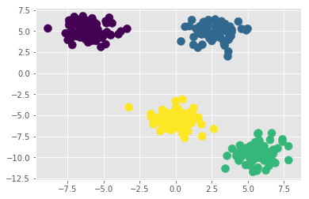

```python
# applying this function to the data matrix we had

centers, labels = find_clusters(X, 4)
plt.scatter(X[:, 0], X[:, 1], c=labels, s=100,\
           cmap='viridis');
```

## Limitations of expectation.maximization

- Expectation-maximization does not guarantee that we will find the globally best solution.
- We must know the number of desired clusters beforehand.
- The decision boundaries of the algorithms are linear.
- The algorithm is slow for large datasets.

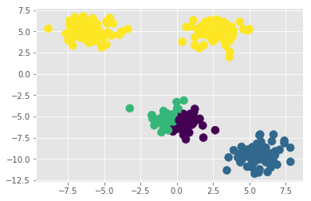

```python
# example of not finding global optimum, change of seed
centers, labels = find_clusters(X, 4, rseed=10)
plt.scatter(X[:, 0], X[:, 1], c=labels, s=100,\
           cmap='viridis');
```

```python
# example of not knowing how many clusters in advance
criteria = (cv2.TERM_CRITERIA_EPS + \
           cv2.TERM_CRITERIA_MAX_ITER, 10, 1.0)
flags = cv2.KMEANS_RANDOM_CENTERS
compactness, labels, centers = cv2.kmeans(X.astype(np.float32),\
    6, None, criteria, 10, flags)
```

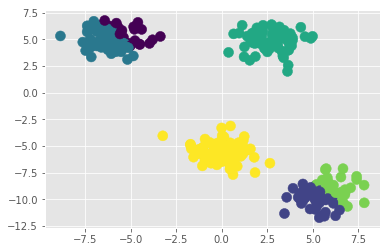

```python
plt.scatter(X[:, 0], X[:, 1], c=labels, s=100, cmap='viridis')
```

We can try the **elbow method**: repeat clustering for a range of *k* values and record the compactness

```python
kvals = np.arange(2, 10)
compactness = []
for k in kvals:
    c, _, _ = cv2.kmeans(X.astype(np.float32), k, None,\
                        criteria, 10, flags)
    compactness.append(c)
```

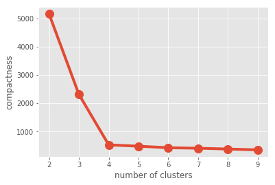

```python
# plot compactness as a function of k
plt.plot(kvals, compactness, 'o-', lw=4, markersize=12)
plt.xlabel('number of clusters')
plt.ylabel('compactness')

# the trick is to pick the "elbow"
```

Other methods:

- Silhouette analysis: studies separation between clusters
- Gaussian mixture models
- Density-based spatial clustering of applications with noise (DBSCAN) and affinity propagation

```python
# example of third caveat: cluster boundaries are linear

from sklearn.datasets import make_moons
X, y = make_moons(200, noise=0.05, random_state=12)
```

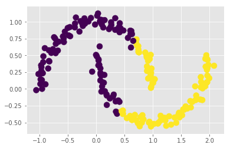

```python
criteria = (cv2.TERM_CRITERIA_EPS + \
           cv2.TERM_CRITERIA_MAX_ITER, 10, 1.0)
flags = cv2.KMEANS_RANDOM_CENTERS
compactness, labels, centers = cv2.kmeans(X.astype(np.float32),\
    2, None, criteria, 10, flags)
plt.scatter(X[:, 0], X[:, 1], c=labels, s=100, cmap='viridis');
```

Can we transform the data into a higher-dimensional feature space? Yes we can!

> We most certainly can. There is a form of kernelized k-means that works akin to the kernel trick for SVMs, called **spectral clustering**.

```python
# scikit-learn implementation
from sklearn.cluster import SpectralClustering
```

> The algorithm uses the same API as all other statistical models: We set optional arguments in the constructor and then call fit_predict on the data. Here, we want to use the graph of the nearest neighbors to compute a higher-dimensional representation of the data and then assign labels using k-means

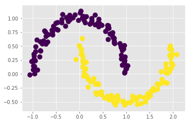

```python
model = SpectralClustering(n_clusters=2,\
    affinity='nearest_neighbors', assign_labels='kmeans')
labels = model.fit_predict(X)
plt.scatter(X[:, 0], X[:, 1], c=labels, s=100, cmap='viridis')
```

**Fourth caveat: k means is slow for a large number of samples**

> You might wonder whether the requirement to access all data points during each iteration is really necessary. For example, you might just use a subset of the data to update the cluster centers at each step. Indeed, this is the exact idea that underlies a variation of the algorithm called **batch-based k-means**.

Look up in scikit-learn: `sklearn.cluster.MiniBatchkMeans`

## Referencias

- Beyeler, Michael. 2017. *Machine Learning for Opencv: Intelligent Image Processing with Python*. Vol. 1. Packt Publishing - ebooks Account.